# Data Science 3: Take Home Exam

Patrik Szigeti

03/29/2020

# Exploratory Data Analysis

```r
# Read in the train and the test datasets
raw_data_train <- fread("data/online_news_popularity/train.csv")
raw_data_test <- fread("data/online_news_popularity/test.csv")

skim(raw_data_train)
```

Data summary

| Name | raw_data_train |
| --- | --- |
| Number of rows | 27752 |
| Number of columns | 60 |
| _______________________ |  |
| Column type frequency: |  |
| numeric | 60 |
| ________________________ |  |
| Group variables | None |

**Variable type: numeric**

| skim_variable | n_missing | complete_rate | mean | sd | p0 | p25 | p50 | p75 | p100 | hist |
| --- | --- | --- | --- | --- | --- | --- | --- | --- | --- | --- |
| n_tokens_title | 0 | 1 | 10.38 | 2.11 | 3.00 | 9.00 | 10.00 | 12.00 | 20.00 | ▁▅▇▁▁ |
| n_tokens_content | 0 | 1 | 546.56 | 471.66 | 0.00 | 246.00 | 409.00 | 717.00 | 7764.00 | ▇▁▁▁▁ |
| n_unique_tokens | 0 | 1 | 0.56 | 4.21 | 0.00 | 0.47 | 0.54 | 0.61 | 701.00 | ▇▁▁▁▁ |
| n_non_stop_words | 0 | 1 | 1.01 | 6.25 | 0.00 | 1.00 | 1.00 | 1.00 | 1042.00 | ▇▁▁▁▁ |
| n_non_stop_unique_tokens | 0 | 1 | 0.70 | 3.90 | 0.00 | 0.63 | 0.69 | 0.75 | 650.00 | ▇▁▁▁▁ |
| num_hrefs | 0 | 1 | 10.92 | 11.40 | 0.00 | 4.00 | 8.00 | 14.00 | 304.00 | ▇▁▁▁▁ |
| num_self_hrefs | 0 | 1 | 3.30 | 3.85 | 0.00 | 1.00 | 3.00 | 4.00 | 116.00 | ▇▁▁▁▁ |
| num_imgs | 0 | 1 | 4.61 | 8.36 | 0.00 | 1.00 | 1.00 | 4.00 | 111.00 | ▇▁▁▁▁ |
| num_videos | 0 | 1 | 1.23 | 4.07 | 0.00 | 0.00 | 0.00 | 1.00 | 91.00 | ▇▁▁▁▁ |
| average_token_length | 0 | 1 | 4.55 | 0.84 | 0.00 | 4.48 | 4.66 | 4.86 | 8.04 | ▁▁▇▃▁ |
| num_keywords | 0 | 1 | 7.23 | 1.91 | 1.00 | 6.00 | 7.00 | 9.00 | 10.00 | ▁▂▇▇▇ |
| data_channel_is_lifestyle | 0 | 1 | 0.05 | 0.23 | 0.00 | 0.00 | 0.00 | 0.00 | 1.00 | ▇▁▁▁▁ |
| data_channel_is_entertainment | 0 | 1 | 0.18 | 0.38 | 0.00 | 0.00 | 0.00 | 0.00 | 1.00 | ▇▁▁▁▂ |
| data_channel_is_bus | 0 | 1 | 0.16 | 0.36 | 0.00 | 0.00 | 0.00 | 0.00 | 1.00 | ▇▁▁▁▂ |
| data_channel_is_socmed | 0 | 1 | 0.06 | 0.23 | 0.00 | 0.00 | 0.00 | 0.00 | 1.00 | ▇▁▁▁▁ |
| data_channel_is_tech | 0 | 1 | 0.19 | 0.39 | 0.00 | 0.00 | 0.00 | 0.00 | 1.00 | ▇▁▁▁▂ |
| data_channel_is_world | 0 | 1 | 0.21 | 0.41 | 0.00 | 0.00 | 0.00 | 0.00 | 1.00 | ▇▁▁▁▂ |
| kw_min_min | 0 | 1 | 26.26 | 69.82 | -1.00 | -1.00 | -1.00 | 4.00 | 377.00 | ▇▁▁▁▁ |
| kw_max_min | 0 | 1 | 1165.99 | 4147.64 | 0.00 | 448.00 | 662.00 | 1000.00 | 298400.00 | ▇▁▁▁▁ |
| kw_avg_min | 0 | 1 | 314.70 | 670.78 | -1.00 | 142.50 | 235.94 | 358.22 | 42827.86 | ▇▁▁▁▁ |
| kw_min_max | 0 | 1 | 13529.57 | 57297.42 | 0.00 | 0.00 | 1400.00 | 7900.00 | 843300.00 | ▇▁▁▁▁ |
| kw_max_max | 0 | 1 | 751996.26 | 214875.42 | 0.00 | 843300.00 | 843300.00 | 843300.00 | 843300.00 | ▁▁▁▁▇ |
| kw_avg_max | 0 | 1 | 258825.28 | 134555.01 | 0.00 | 172477.50 | 244297.86 | 330700.00 | 843300.00 | ▃▇▃▁▁ |
| kw_min_avg | 0 | 1 | 1118.68 | 1138.40 | -1.00 | 0.00 | 1024.77 | 2060.03 | 3613.04 | ▇▃▃▂▂ |
| kw_max_avg | 0 | 1 | 5676.57 | 6346.89 | 0.00 | 3566.30 | 4359.61 | 6018.30 | 298400.00 | ▇▁▁▁▁ |
| kw_avg_avg | 0 | 1 | 3140.74 | 1343.01 | 0.00 | 2387.63 | 2870.55 | 3608.71 | 43567.66 | ▇▁▁▁▁ |
| self_reference_min_shares | 0 | 1 | 4123.98 | 20926.43 | 0.00 | 638.00 | 1200.00 | 2700.00 | 843300.00 | ▇▁▁▁▁ |
| self_reference_max_shares | 0 | 1 | 10401.31 | 41383.32 | 0.00 | 1100.00 | 2800.00 | 7900.00 | 843300.00 | ▇▁▁▁▁ |
| self_reference_avg_sharess | 0 | 1 | 6479.49 | 24979.25 | 0.00 | 978.79 | 2200.00 | 5199.40 | 843300.00 | ▇▁▁▁▁ |
| weekday_is_monday | 0 | 1 | 0.17 | 0.37 | 0.00 | 0.00 | 0.00 | 0.00 | 1.00 | ▇▁▁▁▂ |
| weekday_is_tuesday | 0 | 1 | 0.19 | 0.39 | 0.00 | 0.00 | 0.00 | 0.00 | 1.00 | ▇▁▁▁▂ |
| weekday_is_wednesday | 0 | 1 | 0.19 | 0.39 | 0.00 | 0.00 | 0.00 | 0.00 | 1.00 | ▇▁▁▁▂ |
| weekday_is_thursday | 0 | 1 | 0.18 | 0.39 | 0.00 | 0.00 | 0.00 | 0.00 | 1.00 | ▇▁▁▁▂ |
| weekday_is_friday | 0 | 1 | 0.14 | 0.35 | 0.00 | 0.00 | 0.00 | 0.00 | 1.00 | ▇▁▁▁▁ |
| weekday_is_saturday | 0 | 1 | 0.06 | 0.24 | 0.00 | 0.00 | 0.00 | 0.00 | 1.00 | ▇▁▁▁▁ |
| weekday_is_sunday | 0 | 1 | 0.07 | 0.25 | 0.00 | 0.00 | 0.00 | 0.00 | 1.00 | ▇▁▁▁▁ |
| is_weekend | 0 | 1 | 0.13 | 0.34 | 0.00 | 0.00 | 0.00 | 0.00 | 1.00 | ▇▁▁▁▁ |
| LDA_00 | 0 | 1 | 0.18 | 0.26 | 0.00 | 0.03 | 0.03 | 0.24 | 0.92 | ▇▁▁▁▁ |
| LDA_01 | 0 | 1 | 0.14 | 0.22 | 0.00 | 0.03 | 0.03 | 0.15 | 0.93 | ▇▁▁▁▁ |
| LDA_02 | 0 | 1 | 0.21 | 0.28 | 0.00 | 0.03 | 0.04 | 0.33 | 0.92 | ▇▁▁▁▁ |
| LDA_03 | 0 | 1 | 0.22 | 0.30 | 0.00 | 0.03 | 0.04 | 0.38 | 0.93 | ▇▁▁▁▂ |
| LDA_04 | 0 | 1 | 0.24 | 0.29 | 0.00 | 0.03 | 0.04 | 0.40 | 0.93 | ▇▂▁▁▂ |
| global_subjectivity | 0 | 1 | 0.44 | 0.12 | 0.00 | 0.40 | 0.45 | 0.51 | 1.00 | ▁▃▇▁▁ |
| global_sentiment_polarity | 0 | 1 | 0.12 | 0.10 | -0.39 | 0.06 | 0.12 | 0.18 | 0.73 | ▁▂▇▁▁ |
| global_rate_positive_words | 0 | 1 | 0.04 | 0.02 | 0.00 | 0.03 | 0.04 | 0.05 | 0.16 | ▅▇▁▁▁ |
| global_rate_negative_words | 0 | 1 | 0.02 | 0.01 | 0.00 | 0.01 | 0.02 | 0.02 | 0.18 | ▇▁▁▁▁ |
| rate_positive_words | 0 | 1 | 0.68 | 0.19 | 0.00 | 0.60 | 0.71 | 0.80 | 1.00 | ▁▁▃▇▃ |
| rate_negative_words | 0 | 1 | 0.29 | 0.16 | 0.00 | 0.19 | 0.28 | 0.38 | 1.00 | ▅▇▃▁▁ |
| avg_positive_polarity | 0 | 1 | 0.35 | 0.10 | 0.00 | 0.31 | 0.36 | 0.41 | 1.00 | ▁▇▃▁▁ |
| min_positive_polarity | 0 | 1 | 0.10 | 0.07 | 0.00 | 0.05 | 0.10 | 0.10 | 1.00 | ▇▁▁▁▁ |
| max_positive_polarity | 0 | 1 | 0.76 | 0.25 | 0.00 | 0.60 | 0.80 | 1.00 | 1.00 | ▁▁▅▅▇ |
| avg_negative_polarity | 0 | 1 | -0.26 | 0.13 | -1.00 | -0.33 | -0.25 | -0.19 | 0.00 | ▁▁▂▇▃ |
| min_negative_polarity | 0 | 1 | -0.52 | 0.29 | -1.00 | -0.70 | -0.50 | -0.30 | 0.00 | ▆▆▇▅▅ |
| max_negative_polarity | 0 | 1 | -0.11 | 0.10 | -1.00 | -0.12 | -0.10 | -0.05 | 0.00 | ▁▁▁▁▇ |
| title_subjectivity | 0 | 1 | 0.28 | 0.32 | 0.00 | 0.00 | 0.15 | 0.50 | 1.00 | ▇▂▂▁▂ |
| title_sentiment_polarity | 0 | 1 | 0.07 | 0.27 | -1.00 | 0.00 | 0.00 | 0.15 | 1.00 | ▁▁▇▂▁ |
| abs_title_subjectivity | 0 | 1 | 0.34 | 0.19 | 0.00 | 0.17 | 0.50 | 0.50 | 0.50 | ▃▂▁▁▇ |
| abs_title_sentiment_polarity | 0 | 1 | 0.16 | 0.23 | 0.00 | 0.00 | 0.00 | 0.25 | 1.00 | ▇▂▁▁▁ |
| is_popular | 0 | 1 | 0.20 | 0.40 | 0.00 | 0.00 | 0.00 | 0.00 | 1.00 | ▇▁▁▁▂ |
| article_id | 0 | 1 | 19794.97 | 11441.80 | 2.00 | 9883.50 | 19765.50 | 29699.50 | 39644.00 | ▇▇▇▇▇ |

- By skimming the `raw_data_train` dataset, I can see that there are a lot of dummy variables that should be converted to factors (e.g. `data_channel_is_lifestyle` or `weekday_is_monday`). It’s also apparent that the `is_weekend` variable doesn’t add anything to the data, since we already have `weekday_is_saturday` and `weekday_is_sunday` that determines whether it’s the weekend or not, so it can be removed.
- There seems to be an extreme value in the `n_unique_tokens` variable, which is the rate of unique words in the content, and should be a value between 0 and 1.
- My goal is to predict `is_popular` as a value between 0 and 1 to find out which articles will be shared the most.

# Data Cleaning

In order to avoid duplicate work, I’m merging the train and the test data set for data wrangling.

```r
# Add a set flag to both the train and the test set
raw_data_train$set <- "train"
raw_data_test$set <- "test"

# Add is_popular as NA to the test set for merging
raw_data_test$is_popular <- NA

# Merge the datasets
data <- rbind(raw_data_train, raw_data_test)

# Remove the outlier from n_unique_tokens
data <- data[n_unique_tokens != 701, ]

# Set the dummy variables as factors and remove is_weekend
data$data_channel_is_lifestyle <- factor(data$data_channel_is_lifestyle)
data$data_channel_is_entertainment <- factor(data$data_channel_is_entertainment)
data$data_channel_is_bus <- factor(data$data_channel_is_bus)
data$data_channel_is_socmed <- factor(data$data_channel_is_socmed)
data$data_channel_is_tech <- factor(data$data_channel_is_tech)
data$data_channel_is_world <- factor(data$data_channel_is_world)

data$weekday_is_monday <- factor(data$weekday_is_monday)
data$weekday_is_tuesday <- factor(data$weekday_is_tuesday)
data$weekday_is_wednesday <- factor(data$weekday_is_wednesday)
data$weekday_is_thursday <- factor(data$weekday_is_thursday)
data$weekday_is_friday <- factor(data$weekday_is_friday)
data$weekday_is_saturday <- factor(data$weekday_is_saturday)
data$weekday_is_sunday <- factor(data$weekday_is_sunday)
data$is_weekend <- NULL

# Set is_popular as a factor with labels 'popular' and 'not_popular'
data$is_popular <- factor(data$is_popular, labels = c("not_popular", "popular"))

# Re-create the train set
data_train <- subset(data, set == "train")
data_train$set <- NULL

# Re-create the test set
data_test <- subset(data, set == "test")
data_test$set <- NULL
data_test$is_popular <- NULL

# Remove all dataframes but data_train and data_test
rm(raw_data_test, raw_data_train, data)
```

# Predictions

### Linear Model Prediction

For the linear prediction I’m using 5-fold cross-validation, and training my model with `glm` method.

```r
train_control <- trainControl(
  method = "cv",
  number = 5,
  classProbs = TRUE,
  savePredictions = TRUE
)

set.seed(1234)
linear_model <- train(
  is_popular ~ .,
  data = data_train,
  preProcess = c("center", "scale"),
  method = "glm",
  trControl = train_control
)

lm_roc <- roc(
  predictor = predict(
    linear_model,
    data_train,
    type = "prob",
    decision.values = TRUE)$popular,
  response = data_train$is_popular
)
```

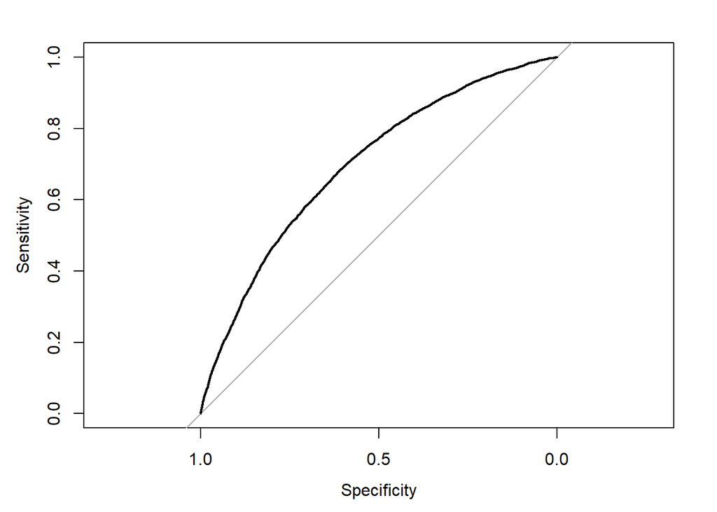

```r
plot(lm_roc)
```

```r
lm_roc$auc
```

```
## Area under the curve: 0.6979
```

The AUC for my linear model is 0.6979, which will serve as the baseline model.

> The linear model prediction’s AUC was **0.67836** on Kaggle.

### Random Forest Prediction

For my baseline random forest, I’m experimenting with different number of variables randomly sampled at each split (`mtry = c(2, 3, 5, 8)`) and different minimum node sizes (`min.node.size = c(5, 10)`).

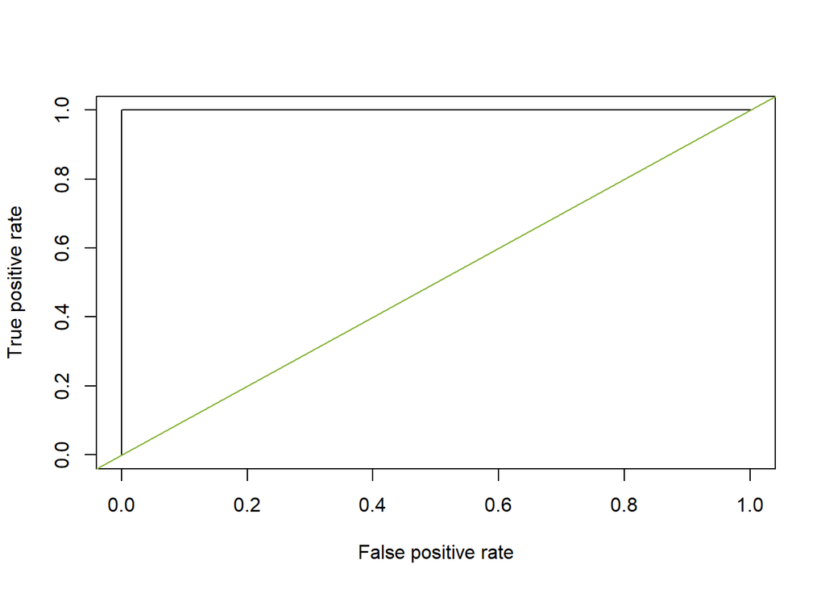

```r
tune_grid <- expand.grid(
  .mtry = c(2, 3, 5, 8),
  .splitrule = "gini",
  .min.node.size = c(5, 10)
)

set.seed(1234)
rf_model <- train(
  is_popular ~ .,
  method = "ranger",
  data = data_train,
  trControl = train_control,
  tuneGrid = tune_grid,
  importance = "impurity"
)

predicted_probabilities <- predict(rf_model, newdata = data_train, type = "prob")
rocr_prediction <- prediction(predicted_probabilities[["popular"]], data_train[["is_popular"]])
plot(performance(rocr_prediction, "tpr", "fpr"), col = "black")
abline(a = 0, b = 1, col = "#8AB63F")
```

As we can see from the ROC curve, the AUC of the random forest prediction is 1 or very close to 1, which means it has a 100% accuracy in-sample, and is over-fitted. This tends to happen when the target of the random forest is a factor variable. The random forest model can still serve as a good base model for an ensemble model later on, but due to its over-fitting nature, it’s not particularly reliable in itself.

> The random forest prediction’s AUC was **0.69660** on Kaggle.

### Gradient Boosting Prediction

Due to the computational power needed for gradient boosting, instead of tuning parameters in a grid, I built three separate GBM models with differing inputs for number of trees, interaction depth, shrinkage and minimum obeservations in a node:

| Model | `n.trees` | `interaction.depth` | `shrinkage` | `n.minobsinnode` |
| --- | --- | --- | --- | --- |
| `gbm_model_1` | 1000 | 1 | 0.001 | 1 |
| `gbm_model_2` | 500 | 5 | 0.1 | 5 |
| `gbm_model_3` | 500 | 10 | 0.1 | 5 |

#### GBM Model 1

```r
gbm_grid_1 <- expand.grid(
  n.trees = 1000,
  interaction.depth = 1,
  shrinkage = 0.001,
  n.minobsinnode = 1
)

set.seed(1234)
gbm_model_1 <- train(
  is_popular ~ .,
  method = "gbm",
  data = data_train,
  trControl = train_control,
  tuneGrid = gbm_grid_1,
  verbose = FALSE
)

gbm_roc_1 <- roc(
  predictor = predict(
    gbm_model_1,
    data_train,
    type = "prob",
    decision.values = TRUE)$popular,
  response = data_train$is_popular
)
```

#### GBM Model 2

```r
gbm_grid_2 <- expand.grid(
  n.trees = 500,
  interaction.depth = 5,
  shrinkage = 0.1,
  n.minobsinnode = 5
)

set.seed(1234)
gbm_model_2 <- train(
  is_popular ~ .,
  method = "gbm",
  data = data_train,
  trControl = train_control,
  tuneGrid = gbm_grid_2,
  verbose = FALSE
)

gbm_roc_2 <- roc(
  predictor = predict(
    gbm_model_2,
    data_train,
    type = "prob",
    decision.values = TRUE)$popular,
  response = data_train$is_popular
)
```

#### GBM Model 3

```r
gbm_grid_3 <- expand.grid(
  n.trees = 500,
  interaction.depth = 10,
  shrinkage = 0.1,
  n.minobsinnode = 5
)

set.seed(1234)
gbm_model_3 <- train(
  is_popular ~ .,
  method = "gbm",
  data = data_train,
  trControl = train_control,
  tuneGrid = gbm_grid_3,
  verbose = FALSE
)

gbm_roc_3 <- roc(
  predictor = predict(
    gbm_model_3,
    data_train,
    type = "prob",
    decision.values = TRUE)$popular,
  response = data_train$is_popular
)
```

#### Select the Best GBM Model

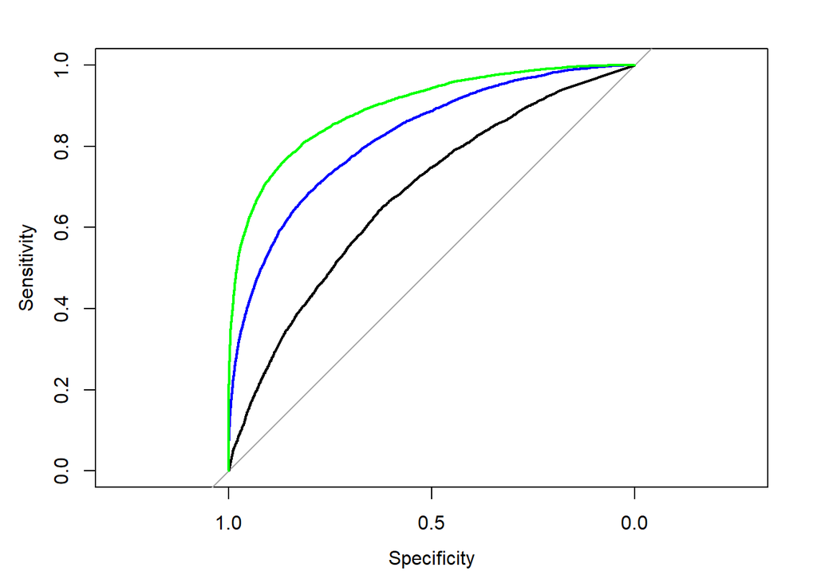

```r
plot(gbm_roc_1)
plot(gbm_roc_2, add = TRUE, col = "blue")
plot(gbm_roc_3, add = TRUE, col = "green")
```

```r
print(paste("AUC of gbm_roc_1:", gbm_roc_1$auc))
```

```
## [1] "AUC of gbm_roc_1: 0.678409952001343"
```

```r
print(paste("AUC of gbm_roc_2:", gbm_roc_2$auc))
```

```
## [1] "AUC of gbm_roc_2: 0.822521131963342"
```

```r
print(paste("AUC of gbm_roc_3:", gbm_roc_3$auc))
```

```
## [1] "AUC of gbm_roc_3: 0.89403193894821"
```

Out of the three, the third GBM model has the highest AUC, and was therefore selected for my submission.

> The best gradient boosting prediction’s AUC was **0.69692** on Kaggle.

### Neural Network Prediction

For my neural network prediction, I searched for two hyper-parameters in the grid:

- The number of units in the hidden layer (`size = c(3, 5, 7, 10, 15)`)
- And a regularization parameter to avoid over-fitting (`decay = c(0.1, 0.5, 1, 1.5, 2, 2.5, 5)`)

```r
tune_grid_nnet <- expand.grid(
  size = c(3, 5, 7, 10, 15),
  decay = c(0.1, 0.5, 1, 1.5, 2, 2.5, 5)
)

set.seed(1234)
nnet_model <- train(
  is_popular ~ .,
  method = "nnet",
  data = data_train,
  trControl = train_control,
  tuneGrid = tune_grid_nnet,
  preProcess = c("center", "scale", "pca"),
  metric = "ROC",
  trace = FALSE
)

nnet_prediction <- prediction(
  predict.train(
    nnet_model,
    newdata = data_train,
    type = "prob")$popular,
  data_train$is_popular
)
performance(nnet_prediction, measure = "auc")@y.values[[1]]
```

```
## [1] 0.7169598
```

> The neural network prediction’s AUC was **0.68940** on Kaggle.

### Ensemble Model

```r
# Initialize H2O
library(h2o)
h2o.no_progress() # suppress progress bars in the outcome
h2o.init(max_mem_size = "8g")
```

[output not shown]

```r
# Create H2O datasets
data_train_h2o <- as.h2o(data_train)
data_test_h2o <- as.h2o(data_test)

# Set the target variable
y <- "is_popular"
X <- setdiff(names(data_train_h2o), y)
```

I decided to use H2O to create an ensemble model from four base-learners, using `deeplearning` as the `metalearner_algoritm`:

- GLM model with 5-fold cross-validation, and tuning the `alpha` regularization hyperparameter (`c(0, 0.25, 0.5, 0.75, 1)`).
- Random forest with 5-fold CV, 500 trees and tuning two different `mtries`, 3 and 5.
- GBM with 500 trees, `learn_rate = c(0.001, 0.01)`, `max_depth = c(5, 10)`, `sample_rate = c(0.7, 0.8)` and `col_sample_rate = c(0.7, 0.8)`.
- Deep learning model with 5-fold CV, 10 epochs, misclassification as the stopping metric and 0.01 as the stopping tolerance with 2 stopping rounds. For the hyper-parameters, I experimented with the input dropout ratio, the learning rate and the hidden layers.

```r
# GLM
glm_grid_h2o <- h2o.grid(
  x = X, y = y,
  training_frame = data_train_h2o,
  family = "binomial",
  algorithm = "glm",
  lambda_search = TRUE,
  nfolds = 5,
  seed = 1234,
  hyper_params = list(
    alpha = c(0, 0.25, 0.5, 0.75, 1)
  ),
  keep_cross_validation_predictions = TRUE
)

# Random Forest
rf_grid_h2o <- h2o.grid(
  x = X, y = y,
  training_frame = data_train_h2o,
  algorithm = "randomForest",
  nfolds = 5,
  seed = 1234,
  hyper_params = list(
    ntrees = 500,
    mtries = c(3, 5)
  ),
  keep_cross_validation_predictions = TRUE
)

# GBM
gbm_grid_h2o <- h2o.grid(
  x = X, y = y,
  training_frame = data_train_h2o,
  algorithm = "gbm",
  ntrees = 500,
  seed = 1234,
  nfolds = 5,
  hyper_params = list(
    learn_rate = c(0.001, 0.01),
    max_depth = c(5, 10),
    sample_rate = c(0.7, 0.8),
    col_sample_rate = c(0.7, 0.8)
  ),
  keep_cross_validation_predictions = TRUE
)

# Deep Learning
dl_grid_h2o <- h2o.grid(
  x = X, y = y,
  training_frame = data_train_h2o,
  algorithm = "deeplearning",
  seed = 1234,
  nfolds = 5,
  epochs = 10,
  stopping_metric = "misclassification",
  stopping_tolerance = 1e-2,
  stopping_rounds = 2,
  hyper_params = list(
    input_dropout_ratio = c(0, 0.05),
    rate = c(0.01, 0.02),
    hidden = list(c(32, 16, 8), c(32, 32))
  ),
  keep_cross_validation_predictions = TRUE
)
```

After the grid search, I selected the models with the highest AUC from each base-learner to feed into the ensemble model.

```r
# GLM
glm_model_h2o <- h2o.getModel(
  h2o.getGrid(
    glm_grid_h2o@grid_id,
    sort_by = "auc",
    decreasing = TRUE
  )@model_ids[[1]]
)

# Random Forest
rf_model_h2o <- h2o.getModel(
  h2o.getGrid(
    rf_grid_h2o@grid_id,
    sort_by = "auc",
    decreasing = TRUE
  )@model_ids[[1]]
)

# GBM
gbm_model_h2o <- h2o.getModel(
  h2o.getGrid(
    gbm_grid_h2o@grid_id,
    sort_by = "auc",
    decreasing = TRUE
  )@model_ids[[1]]
)

# Deep Learning
dl_model_h2o <- h2o.getModel(
  h2o.getGrid(
    dl_grid_h2o@grid_id,
    sort_by = "auc",
    decreasing = TRUE
  )@model_ids[[1]]
)
```

Training the ensemble model:

```r
ensemble_model_dl <- h2o.stackedEnsemble(
  X, y,
  training_frame = data_train_h2o,
  metalearner_algorithm = "deeplearning",
  seed = 1234,
  base_models = list(
    rf_model_h2o,
    glm_model_h2o,
    gbm_model_h2o,
    dl_model_h2o
  )
)

print(h2o.auc(h2o.performance(ensemble_model_dl, newdata = data_train_h2o)))
```

```
## [1] 0.9781161
```

# Conclusion

- I believe that with more computational power, I would’ve been able to fine-tune the models and achieve better scores, but my computer couldn’t handle the load while trying to tune the number of trees for the random forest between 500 and 1000, just to give one example.
- In an ideal world, I would’ve also liked to see how my ensemble model performs if I provide a netural net as a base-learner in addition to the ones I did, but I’m still happy with the score I was able to achieve.